# Curve Sketching

The figure illustrates a means to *sketch* a sine curve – identify as many of the following values as you can: asymptotic behaviour, periodic behaviour, vertical asymptotes, $y$ intercept, $x$ intercepts, local peaks and valleys (extrema). With these, a sketch fills in between the points/lines associated with these values.

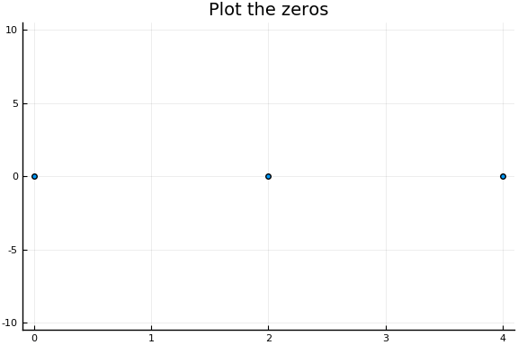

After identifying asymptotic behaviours, a curve sketch involves identifying the $y$ intercept, if applicable; the $x$ intercepts, if possible; and the local extrema. From there a sketch fills in between the points. In this example, the periodic function $f(x) = 10\cdot\sin(\pi/2\cdot x)$ is sketched over $[0,4]$.

Though this approach is most useful for hand-sketches, the underlying concepts are important for properly framing graphs made with the computer.

We can easily make a graph of a function over a specified interval. What is not always so easy is to pick an interval that shows off the feature of interest. In the section on rational functions there was a discussion about how to draw graphs for rational functions so that horizontal and vertical asymptotes can be seen. These are properties of the "large." In this section, we build on this, but concentrate now on more local properties of a function.

## Positive and increasing on an interval

Before beginning, we need some vocabulary:

> A function $f$ is *positive* on an interval $I$ if for any $a$ in $I$ it must be that $f(a) > 0$.

Of course, we define *negative* in a parallel manner. The intermediate value theorem says a continuous function can not change from positive to negative without crossing $0$. This is not the case for functions with jumps, of course.

> A function, $f$, is (strictly) *increasing* on an interval $I$ if for any $a < b$ it must be that $f(a) < f(b)$.

The word strictly is related to the inclusion of the $<$ precluding the possibility of a function being flat over an interval that the $\leq$ inequality would allow.

A parallel definition with $a < b$ implying $f(a) > f(b)$ would be used for a *strictly decreasing* function.

This helper function plots the function `f` twice: the second time only when the second function `g` is positive.

```julia
function plotif(f, g, a, b)
       xs = range(a, stop=b, length=251)
       ys = f.(xs)
       cols = [gx < 0 ? :red : :blue for gx in g.(xs)]
       p = plot(xs, ys, color=cols, linewidth=5, legend=false)
       p
end
```

Such a function is defined for us in the accompanying package, loaded with

```julia
using CalculusWithJulia
```

To see where a function is positive, we simply pass the function object in for *both* `f` and `g` above. For example, let's look at where $f(x) = \sin(x)$ is positive:

```julia
f(x) = sin(x)
plotif(f, f, -2pi, 2pi)
```

Let's graph with `cos` in the masking spot and see what happens:

```julia
plotif(sin, cos, -2pi, 2pi)
```

Maybe surprisingly, we see that the increasing parts of the sine curve are now highlighted. Of course, the cosine is the derivative of the sine function, now we discuss that this is no coincidence.

For the sequel, we will use `f'` notation to find numeric derivatives, with the notation being defined in the `CalculusWithJulia` package using the `ForwardDiff` package.

## Relative extrema

When a function changes from increasing to decreasing, or decreasing to increasing, it will have a peak or a valley. We call such points relative extrema. A definition may be:

> The function $f(x)$ has a *relative maximum* at $x$ if the value $f(x)$ is an *absolute maximum* for some open interval containing $x$. Similarly, a *relative minimum* is defined.

If $x$ is a relative maximum, then there is some $a < x < b$ with $f(u) \leq f(x)$ for any $u \in (a,b)$. This does not say there is an absolute maximum over any interval $I$ at $x$, but rather there is some (open) interval for which $f(x)$ is an absolute maximum.

[Fermat's](http://tinyurl.com/nfgz8fz) theorem implies that any local extrema must occur at a critical point of the function $f(x)$.

## The relationship of the derivative and increasing

Suppose $f(x)$ has a derivative on $I$ . Then

> If $f'(x)$ is positive on an interval $I=(a,b)$, then $f(x)$ is strictly increasing on $I$.

Meanwhile,

> If a function $f(x)$ is increasing on $I$, then $f'(x) \geq 0$.

The technicality being the equality parts. In the second statement, we have the derivative is non-negative, as we can't guarantee it is positive, even if we considered just strictly increasing functions.

We can see by the example of $f(x) = x^3$ that strictly increasing functions can have a zero derivative, at a point.

The mean value theorem provides the reasoning behind the first statement: on $I$, the slope of any secant line between $d < e$ (both in $I$) is matched by the slope of some tangent line, which by assumption will always be positive. If the secant line slope is written as $(f(e) - f(d))/(e - d)$ with $d < e$, then it is clear then that $f(e) - f(d) > 0$, or $f(e) > f(d)$.

The second part, follows from the secant line equation. The derivative can be written as a limit of secant-line slopes, each of which is positive. The limit of positive things can only be non-negative, though there is no guarantee the limit will be positive.

So, to visualize where a function is increasing, we can just pass in the derivative as the masking function in our `plotif` function, as long as we are wary about places with $0$ derivative (flat spots).

For example, here we see where a more complicated function is increasing by passing in its derivative to `plotif`:

```julia
f(x) = sin(pi*x) * (x^3 - 4x^2 + 2)
plotif(f, f', -2, 2)
```

### First derivative test

We know since Fermat that relative maxima and minima occur at *critical* points. But what is **not** true is that all critical points correspond to relative maxima and minima. Again, $f(x)=x^3$ provides the example at $x=0$. This is a critical point, but clearly not a relative maximum or minimum–-it is just a slight pause for a strictly increasing function.

When will a critical point correspond to a relative maximum or minimum? That question can be answered by considering the first derivative.

> *The first derivative test*: If $c$ is a critical point for $f(x)$ and *if* $f'(x)$ changes sign at $x=c$, then $f(c)$ will be either a relative maximum or a relative minimum. It will be a relative maximum if the derivative changes sign from $+$ to $-$ and a relative minimum if the derivative changes sign from $-$ to $+$. If $f'(x)$ does not change sign at $c$, then $(c,f(c))$ is *not* a relative maximum or minimum.

The classification part, should be clear: e.g., if the derivative is positive then negative, the function $f$ will increase to $(c,f(c))$ then decrease from $(c,f(c))$–-so a local maximum.

Our definition of critical point *assumes* $f(c)$ exists, as $c$ is in the domain of $f$. With this assumption, vertical asymptotes are avoided. However, it need not be that $f'(c)$ exists. The absolute value function at $x=0$ provides an example: this point is a critical point where the derivative changes sign, but is not defined exactly at $x=0$. Regardless, it is guaranteed that $(c,f(c))$ will be a relative minimum by the first derivative test.

##### Example

Consider the function $f(x) = e^{-\lvert x\rvert} \cos(\pi x)$ over $[-3,3]$:

```julia
f(x) = exp(-abs(x)) * cos(pi * x)
plotif(f, f', -3, 3)
```

We can see the first derivative test in action: at the peaks and valleys–-the relative extrema–-the color changes, as the function changes from increasing to decreasing or vice versa.

##### Example

Produce a graph of the function $f(x) = x^4 -13x^3 + 56x^2-92x + 48$.

We identify this as a fourth-degree polynomial with postive leading coefficient. Hence it will eventually look $U$-shaped. If we graph over a too-wide interval, that is all we will see. Rather, we do some work to produce a graph that shows the zeros, peaks, and valleys of $f(x)$. To do so, we need to know the extent of the zeros. We can try some theory, but instead we just guess and if that fails, will work harder:

```julia
f(x) = x^4 - 13x^3 + 56x^2 -92x + 48
rts = find_zeros(f, -10, 10)
```

```
4-element Array{Float64,1}:
 0.9999999999999999
 2.000000000000005
 4.000000000000004
 6.000000000000003
```

As we found $4$ roots, we know by the fundamental theorem of algebra we have them all. This means, our graph need not focus on values much larger than $6$ or much smaller than $1$.

To know where the peaks and valleys are, we look for the critical points:

```julia
cps = find_zeros(f', 1, 6)
```

```
3-element Array{Float64,1}:
 1.4257862014364733
 3.0704645527012464
 5.253749245862282
```

Because we have the $4$ distinct zeros, we must have the peaks and valleys appear in an interleaving manner, so a search over $[1,6]$ finds all three critical points and without checking, they must correspond to relative extrema.

We finally check that if we were to just use $[0,7]$ as a domain to plot over that the function doesn't get too large to mask the oscillations. This could happen if the $y$ values at the end points are too much larger than the $y$ values at the peaks and valleys, as only so many pixels can be used within a graph. For this we have:

```julia
f.([0, cps..., 7])
```

```
5-element Array{Float64,1}:
  48.0
  -2.8788980209096167
   6.035382559783841
 -12.949453288874281
  90.0
```

The values at $0$ and at $7$ area a bit large, and since we know the graph is eventually $U$-shaped, this offers no insight. So we narrow the range a bit for the graph:

```julia
plot(f, 0.5, 6.5)
```

##### Example

Find all the relative maxima and minima of the function $f(x) = \sin(\pi \cdot x) \cdot (x^3 - 4x^2 + 2)$ over the interval $[-2, 2]$.

We will do so numerically, rather than attempt this algebraically. For this task we first need to gather the critical points. As each of the pieces of $f$ are everywhere differentiable and no quotients are involved, the function $f$ will be everywhere differentiable. As such, only zeros of $f'(x)$ can be critical points. We find these with

```julia
f(x) = sin(pi*x) * (x^3 - 4x^2 + 2)
cps = find_zeros(f', -2, 2)
```

```
6-element Array{Float64,1}:
 -1.6497065688663188
 -0.8472574303034358
 -0.3264827018362353
  0.35183579595045034
  0.8981933926622453
  1.6165308438251855
```

```julia
plot(f', -2, 2, legend=false)
plot!(zero)
scatter!(cps, 0*cps)
```

We see the six zeros as stored in `cps` and note that at each the function clearly crosses the $x$ axis.

From this last graph of the derivative we can also characterize the graph of $f$: The left-most critical point coincides with a relative minimum of $f$, as the derivative changes sign from negative to positive. The critical points then alternate relative maximum, relative minimum, relative maximum, relative, minimum, and finally relative maximum.

##### Example

Consider the function $f(x) = \sqrt{\lvert x^2 - 1\rvert}$. Find the critical points and characterize them as relative extrema or not.

We will apply the same approach, but need to get a handle on how large the values can be. The function is a composition of three functions. We should expect that the only critical points will occur when the interior polynomial, $x^2-1$ has values of interest, which is around the interval $(-1, 1)$. So we look to the slightly wider interval $[-2, 2]$:

```julia
f(x) = sqrt(abs(x^2 - 1))
cps = find_zeros(f', -2, 2)
```

```
3-element Array{Float64,1}:
 -0.9999999999999999
  0.0
  0.9999999999999999
```

We see the three values $-1$, $0$, $1$ that correspond to the two zeros and the relative minimum of $x^2 - 1$. We could graph things, but instead we characterize these values using a sign chart. A continuous function only can change sign when it crosses $0$ and the derivative will be continuous, except possibly at the three values above.

We can then pick intermediate values to test for positive or negative values:

```julia
pts = union(-2, cps, 2)  # this includes the endpoints (a, b) and the critical points
test_pts = pts[1:end-1] + diff(pts)/2 # midpoints of intervals between pts
[test_pts sign.(f'.(test_pts))]
```

```
4×2 Array{Float64,2}:
 -1.5  -1.0
 -0.5   1.0
  0.5  -1.0
  1.5   1.0
```

Reading this we have:

- the derivative changes sign from negative to postive at $x=-1$, so $f(x)$ will have a relative minimum.
- the derivative changes sign from positive to negative at $x=0$, so $f(x)$ will have a relative maximum.
- the derivative changes sign from negative to postive at $x=1$, so $f(x)$ will have a relative minimum.

Just for fun, we define a function to print `+` or `-` instead of just using `sign`:

```julia
plus_or_minus(x, tol=1e-12) = x > tol ? "+" : (x < -tol ? "-" : "0")
[test_pts plus_or_minus.(f'.(test_pts))]
```

```
4×2 Array{Any,2}:
 -1.5  "-"
 -0.5  "+"
  0.5  "-"
  1.5  "+"
```

We did this all without graphs. But, let's look at the graph of the derivative:

```julia
plot(f', -2, 2)
```

We see asymptotes at $x=-1$ and $x=1$! These aren't zeroes of $f'(x)$, but rather where $f'(x)$ does not exist. The conclusion is correct – each of $-1$, $0$ and $1$ are critical points with the identified characterization–-but not for the reason that they are all zeros.

```julia
plot(f, -2, 2)
```

Finally, why does `find_zeros` find these values that are not zeros of $f'(x)$? It uses the bisection algorithm on bracketing intervals to find zeros which are guaranteed by the intermediate value theorem. But we see from the graph that $f'(x)$ is not continuous. Still the algorithm will also converge to values where the function *jumps* over $0$, which this function clearly does.

##### Example

Consider the function $f(x) = \sin(x) - x$. Characterize the critical points.

We will work symbolically for this example.

```julia
f(x) = sin(x) - x
@vars x
fp = diff(f(x), x)
cps = solve(fp)
```

\[ \left[ \begin{array}{r}0\\2 \pi\end{array} \right] \]

We get values of $0$ and $2\pi$. Let's look at the derivative at these points:

At $x=0$ we have to the left and right signs found by

```julia
vals = fp.([-1/10, 1/10])
[vals plus_or_minus.(vals)]
```

```
2×2 Array{Any,2}:
 -0.00499583472197429  "-"
 -0.00499583472197429  "-"
```

Both are negative. The derivative does not change sign at $0$, so the critical point is neither a relative minimum or maximum.

What about at $2\pi$? We do something similar:

```julia
vals = fp.(2*pi .+ [-1/10,  1/10])
[vals plus_or_minus.(vals)]
```

```
2×2 Array{Any,2}:
 -0.00499583472197418  "-"
 -0.00499583472197418  "-"
```

Again, both negative. The function $f(x)$ is just decreasing near $2\pi$, so again the critical point is neither a relative minimum or maximum.

A graph verifies this:

```julia
plot(f, -3pi, 3pi)
```

We see that at $0$ and $2\pi$ there are "pauses" as the function decreases. We should also see that this pattern repeats. The critical points found by `solve` are only those within a certain domain. Any value that satisfies $\cos(x) - 1 = 0$ will be a critical point, and there are infinitely many of these of the form $n \cdot 2\pi$ for $n$ an integer.

As a comment, the `solveset` function, which is replacing `solve`, returns the entire collection of zeros:

```julia
solveset(fp)
```

\begin{equation*}\left\{2 n \pi\; |\; n \in \mathbb{Z}\right\}\end{equation*}

##### Example

Suppose you know $f'(x) = (x-1)\cdot(x-2)\cdot (x-3) = x^3 - 6x^2 + 11x - 6$ and $g'(x) = (x-1)\cdot(x-2)^2\cdot(x-3)^3 = x^6 -14x^5 +80x^4-238x^3+387x^2-324x+108$.

How would the graphs of $f(x)$ and $g(x)$ differ, as they share identical critical points?

For the graph of $g(x)$ we can apply the same analysis. Thinking for a moment, we see as the factor $(x-2)^2$ comes as a power of $2$, the derivative of $g(x)$ will not change sign at $x=2$, so there is no relative extreme value there. However, at $x=3$ the factor has an odd power, so the derivative will change sign at $x=3$. So, as $g'(x)$ is positive for large *negative* values, there will be a relative maximum at $x=1$ and, as $g'(x)$ is positive for large *positive* values, a relative minimum at $x=3$.

The latter is consistent with a $7$th degree polynomial with positive leading coefficient. It is intuitive that since $g'(x)$ is a $6$th degree polynomial, $g(x)$ will be a $7$th degree one, as the power rule applied to a polynomial results in a polynomial of lesser degree by one.

## Concavity

Consider the function $f(x) = x^2$. Over this function we draw some secant lines for a few pairs of $x$ values:

This is a special property not shared by all functions. Let $I$ be an open interval.

> **Concave up**: A function $f(x)$ is concave up on $I$ if for any $a < b$ in $I$, the secant line between $a$ and $b$ lies above the graph of $f(x)$ over $[a,b]$.

> If $f'(x)$ exists and is *increasing* on $(a,b)$ then $f(x)$ is concave up on $(a,b)$.

Similarly, if a function has a decreasing derivative on $I$ then it will be concave down on $I$.

The relationship between increasing functions and their derivatives–-if $f'(x) > 0 $ on $I$ it is increasing on $I$–- gives this second characterization of concavity when the second derivative exists:

> If $f''(x)$ exists and is positive on $I$, then $f(x)$ is concave up on $I$.

This follows, as we can think of $f''(x)$ as just the first derivative of the function $f'(x)$, so the assumption will force $f'(x)$ to exist and be increasing, and hence $f(x)$ to be concave up.

##### Example

Let's look at the function $x^2 \cdot e^{-x}$ for positive $x$. A quick graph shows the function is concave up, then down, then up in the region plotted:

```julia
f(x) = x^2 * exp(-x)
plotif(f, f'', 0, 8)
```

From the graph, we would expect that the second derivative–-which is continuous–-would have two zeros on $[0,8]$:

```julia
ips = find_zeros(f'', 0, 8)
```

```
2-element Array{Float64,1}:
 0.5857864376269049
 3.414213562373095
```

As well, between the zeros we should have the sign pattern `+`, `-`, and `+`, as we verify:

```julia
ps = [0, 1, 4]
[ps plus_or_minus.(f''.(ps))]
```

```
3×2 Array{Any,2}:
 0  "+"
 1  "-"
 4  "+"
```

### Second derivative test

Concave up functions are "opening" up, and often just $U$-shaped. At a relative minimum, the graph will be concave up, and conversely concave down at a relative maximum. This observation becomes:

If $f''(c)$ is positive in an interval about $c$, then $f''(c) > 0$ implies the function is concave up at $x=c$, Concave up implies the derivative is increasing so must go from negative to positive at the critical point.

The second derivative test is *inconclusive* when $f''(c)=0$. No such general statement exists, as there isn't enough information. For example, the function $f(x) = x^3$ has $0$ as a critical point, $f''(0)=0$ and the value does not correspond to a relative maximum or minimum. On the other hand $f(x)=x^4$ has $0$ as a critical point, $f''(0)=0$ is a relative minimum.

##### Example

```julia
f(x) = x^5 - 2x^4 + x^3
cps = find_zeros(f', -3, 3)
```

```
3-element Array{Float64,1}:
 0.0
 0.5999999999999999
 1.0
```

```julia
cps = [0.0, 0.6, 1.0]
```

```
3-element Array{Float64,1}:
 0.0
 0.6
 1.0
```

We can check the sign of the second derivative for each critical point:

```julia
vals = f''.(cps)
[cps plus_or_minus.(vals)]
```

```
3×2 Array{Any,2}:
 0.0  "0"
 0.6  "-"
 1.0  "+"
```

That $f''(0.6) < 0$ implies that at $0.6$, $f(x)$ will have a relative maximum. As $f''(1) > 0$, the second derivative test says at $x=1$ there will be a relative minimum. That $f''(0) = 0$ says that only that there **may** be a relative maximum or minimum at $x=0$, as the second derivative test does not speak to this situation.

This should be consistent with this graph, where $-0.25$, and $1.25$ are chosen to capture the zero at $0$ and the two relative extrema:

```julia
plotif(f, f'', -0.25, 1.25)
```

For the graph we see that $0$ **is** not a relative maximum or minimum. We could have seen this numerically by checking the first derivative test, and noting there is no sign change:

```julia
plus_or_minus.(f'.([-0.1, 0.1]))
```

```
2-element Array{String,1}:
 "+"
 "+"
```

### Inflection points

An inflection point is a value where the *second* derivative of $f$ changes sign. At an inflection point the derivative will change from increasing to decreasing (or vice versa) and the function will change from concave up to down (or vice versa).

We can use the `find_zeros` function to find inflection points, by passing in the second derivative function. For example, consider the bell-shaped function

\[ ~ f(x) = e^{-x^2/2}. ~ \]

A graph suggests relative a maximum at $x=0$, a horizontal asymptote of $y=0$, and two inflection points:

```julia
f(x) = exp(-x^2/2)
plotif(f, f'', -3, 3)
```

The inflection points can be found directly, if desired, or numerically with:

```julia
find_zeros(f'', -3, 3)
```

```
2-element Array{Float64,1}:
 -1.0
  1.0
```

(The `find_zeros` function may return points which are not inflection points. It primarily returns points where $f''(x)$ changes sign, but may also find points where $f''(x)$ is $0$ yet does not change sign at $x$.)

##### Example

Graph the function

\[ ~ f(x) = \frac{(x-1)\cdot(x-3)^2}{x \cdot (x-2)}. ~ \]

Not much to do here if you are satisfied with a graph that only gives insight into the asymptotes of this rational function:

```julia
f(x) = ( (x-1)*(x-3)^2 ) / (x * (x-2) )
plot(f, -10, 10)
```

We can see the slant asymptote and hints of vertical asymptotes, but, we'd like to see more of the basic features of the graph.

To identify how wide a viewing window should be, for the rational function the asymptotic behaviour is determined after the concavity is done changing and we are past all relative extrema, so we should take an interval that include all potential inflection points and critical points:

```julia
cps = find_zeros(f', -10, 10)
poss_ips = find_zero(f'', (-10, 10))
extrema(union(cps, poss_ips))
```

```
(-2.1527576020103956, 3.0)
```

So a range over $[-5,5]$ should display the key features including the slant asymptote.

Previously we used the `trimplot` function defined in `CalculusWithJulia` to avoid the distortion that vertical asymptotes can have:

```julia
trimplot(f, -5, 5)
```

With this graphic, we can now clearly see in the graph the two zeros at $x=1$ and $x=3$, the vertical asymptotes at $x=0$ and $x=2$, and the slant asymptote.

##### Example

The graph `f1` has constant velocity, so the position is a straight line with slope $v_0$. The graph `f2` is similar, though for first and last 30 seconds, the car does not move, so must move faster during the time it moves. A more realistic graph would be `f3`. The position increases continuously, as do the others, but the velocity changes more gradually. The initial velocity is less than $v_0$, but eventually gets to be more than $v_0$, then velocity starts to increase less. At no point is the velocity not increasing, for `f3`, the way it is for `f2` after a minute and a half.

The rate of change of the velocity is the acceleration. For `f1` this is zero, for `f2` it is zero as well–-when it is defined. However, for `f3` we see the increase in velocity is positive in the first minute, but negative in the second minute. This fact relates to the concavity of the graph. As acceleration is the derivative of velocity, it is the second derivative of position–-the graph we see. Where the acceleration is *positive*, the position graph will be concave *up*, where the acceleration is *negative* the graph will be concave *down*. The point $t=1$ is an inflection point, and would be felt by most riders.

## Questions

###### Question

Consider this graph:

```julia
plot(airyai, -5, 0)  # airyai in `SpecialFunctions` loaded with `CalculusWithJulia`
```

On what intervals (roughly) is the function positive?

$(-5, -4.2)$

$(-5, -4.2)$ and $(-2.5, 0)$

$(-4.2, -2.5)$

$(-3.2,-1)$

###### Question

Consider this graph:

$(-5.0, -4.0)$ and $(-4, -3)$

$(-25.0, 0.0)$

$(-5.0, -4.0)$

$(-4.0, -3.0)$

###### Question

Consider this graph

$(-3.8, -3.0$

$(-5.0, -3.8)$

$(-4.7, -3.0)$

$(-0.17, 0.17)$

###### Question

Consider this graph

$(-3.0, -0.6)$ and $(0.6, 3.0)$

$(-0.6, 0.6)$

$(-3.0, 3.0)$

$(0.1, 1.0)$

###### Question

Consider this graph

Vertical asymptotes at $x=-1$ and $x=1$ and a horizontal asymptote $y=1$

Just vertical asymptotes at $x=-1$ and $x=1$

Just a horizontal asymptote, $y=0$

Vertical asymptotes at $x=-1$ and $x=1$ and a slant asymptote

###### Question

If it is known that:

- A function $f(x)$ has critical points at $x=-1, 0, 1$
- at $-2$ an $-1/2$ the values are: $f'(-2) = 1$ and $f'(-1/2) = -1$.

What can be concluded?

Nothing

That the critical point at $-1$ is a relative maximum

That the critical point at $-1$ is a relative minimum

That the critical point at $0$ is a relative maximum

That the critical point at $0$ is a relative minimum

###### Question

Mystery function $f(x)$ has $f'(2) = 0$ and $f''(0) = 2$. What is the *most* you can say about $x=2$?

$f(x)$ is continuous at 2

$f(x)$ is continuous and differentiable at 2

$f(x)$ is continuous and differentiable at 2 and has a critical point

$f(x)$ is continuous and differentiable at 2 and has a critical point that is a relative minimum by the second derivative test

###### Question

Find the smallest critical point of $f(x) = x^3 e^{-x}$.

###### Question

How many critical points does $f(x) = x^5 - x + 1$ have?

###### Question

How many inflection points does $f(x) = x^5 - x + 1$ have?

###### Question

At $c$, $f'(c) = 0$ and $f''(c) = 1 + c^2$. Is $(c,f(c))$ a relative maximum? ($f$ is a "nice" function.)

No, it is a relative minimum

Yes

No, the second derivative test is possibly inconclusive

###### Question

At $c$, $f'(c) = 0$ and $f''(c) = c^2$. Is $(c,f(c))$ a relative minimum? ($f$ is a "nice" function.)

No, the second derivative test is possibly inconclusive if $c=0$, but otherwise yes

No, it is a relative maximum

Yes

###### Question

Yes

No

###### Question

Yes

No

###### Question

Yes

No

###### Question

The critical points are at $x=1$ (a relative minimum), $x=2$ (a relative minimum), and $x=3$ (a relative minimum).

The critical points are at $x=1$ (a relative maximum), $x=2$ (not a relative extrema), and $x=3$ (not a relative extrema).

The critical points are at $x=1$ (a relative minimum), $x=2$ (not a relative extrema), and $x=3$ (not a relative extrema).

The critical points are at $x=1$ (a relative minimum), $x=2$ (not a relative extrema), and $x=3$ (a relative minimum.

##### Question

You know $f''(x) = (x-1)^3$. What do you know about $f(x)$?

The function is concave down over $(-\infty, 1)$ and concave up over $(1, \infty)

The function is negative over $(-\infty, 1)$ and positive over $(1, \infty)

The function is decreasing over $(-\infty, 1)$ and increasing over $(1, \infty)

##### Question

While driving we accelerate to get through a light before it turns red. However, at time $t_0$ a car cuts in front of us and we are forced to break. If $s(t)$ represents position, what is $t_0$:

A zero of the function

A critical point for the function

An inflection point for the function

##### Question

```julia
K, P0, a = 50, 5, exp(1/4)
egrowth(t) = P0 * a^t
lgrowth(t) = K * P0 * a^t / (K + P0*(a^t-1))

plot([egrowth, lgrowth], 0, 5)
```

Does a plot over $[0,50]$ show qualitatively similar behaviour?

Yes

No

Exponential growth has $P''(t) = P_0 a^t \log(a)^2 > 0$, so has no inflection point. By plotting over a sufficiently wide interval, can you answer: does the logistic growth model have an inflection point?

Yes

No

If yes, find it numerically:

The available resources are quantified by $K$. As $K \rightarrow \infty$ what is the limit of the logistic growth model:

The exponential growth model

The limit is $P_0$

The limit does not exist

##### Question

The plotting algorithm for plotting functions starts with a small initial set of points over the specified interval ($21$) and then refines those sub-intervals where the second derivative is determined to be large.

Why are sub-intervals where the second derivative is large different than those where the second derivative is small?

The function will be much larger (in absolute value) when the second derivative is large, so there needs to be more points to capture the shape

The function will increase (or decrease) rapidly when the second derivative is large, so there needs to be more points to capture the shape

The function will have more curvature when the second derivative is large, so there needs to be more points to capture the shape

##### Question

Is there a nice algorithm to identify what domain a function should be plotted over to produce an informative graph? [Wilkinson](https://www.cs.uic.edu/~wilkinson/Publications/plotfunc.pdf) has some suggestions. (Wilkinson is well known to the `R` community as the specifier of the grammar of graphics.) It is mentioned that "finding an informative domain for a given function depends on at least three features: periodicity, asymptotics, and monotonicity."

Why would periodicity matter?

An informative graph need only show a part of the period, as the rest can be inferred.

An informative graph only needs to show one or two periods, as others can be inferred.

An informative graph needs to show several periods, as that will allow proper computation for the $y$ axis range.

Why should asymptotics matter?

A slant asymptote must be plotted over a very wide domain so that it can be identified.

A horizontal asymptote must be plotted from $-\infty$ to $\infty$

A vertical asymptote can distory the $y$ range, so it is important to avoid too-large values

Monotonicity means increasing or decreasing. This is important for what reason?

For monotonic regions, a function is basically a straight line

For monotonic regions, the function will have a vertical asymptote, so the region should not be plotted

For monotonic regions, a large slope or very concave function might require more care to plot